# Homework 2

4375 Machine Learning with Dr. Mazidi

Cris Chou

This homework gives practice in using linear regression in two parts:

- Part 1 Simple Linear Regression (one predictor)
- Part 2 Multiple Linear Regression (many predictors)

You will need to install package ISLR at the console, not in your script.

# Problem 1: Simple Linear Regression

## Step 1: Initial data exploration

- Load library ISLR (install.packages() at console if needed)
- Use names() and summary() to learn more about the Auto data set
- Divide the data into 75% train, 25% test, using seed 1234

```r
# your code here

#install.packages("ISLR")
df <- ISLR::Auto
names(df)
```

```
## [1] "mpg"          "cylinders"    "displacement" "horsepower"   "weight"
## [6] "acceleration" "year"         "origin"       "name"
```

```r
summary(df)
```

```
##       mpg          cylinders      displacement     horsepower        weight
##  Min.   : 9.00   Min.   :3.000   Min.   : 68.0   Min.   : 46.0   Min.   :1613
##  1st Qu.:17.00   1st Qu.:4.000   1st Qu.:105.0   1st Qu.: 75.0   1st Qu.:2225
##  Median :22.75   Median :4.000   Median :151.0   Median : 93.5   Median :2804
##  Mean   :23.45   Mean   :5.472   Mean   :194.4   Mean   :104.5   Mean   :2978
##  3rd Qu.:29.00   3rd Qu.:8.000   3rd Qu.:275.8   3rd Qu.:126.0   3rd Qu.:3615
##  Max.   :46.60   Max.   :8.000   Max.   :455.0   Max.   :230.0   Max.   :5140
##
##   acceleration        year           origin                      name
##  Min.   : 8.00   Min.   :70.00   Min.   :1.000   amc matador       :  5
##  1st Qu.:13.78   1st Qu.:73.00   1st Qu.:1.000   ford pinto        :  5
##  Median :15.50   Median :76.00   Median :1.000   toyota corolla    :  5
##  Mean   :15.54   Mean   :75.98   Mean   :1.577   amc gremlin       :  4
##  3rd Qu.:17.02   3rd Qu.:79.00   3rd Qu.:2.000   amc hornet        :  4
##  Max.   :24.80   Max.   :82.00   Max.   :3.000   chevrolet chevette:  4
##                                                  (Other)           :365
```

```r
set.seed(1234)
i <- sample(1:nrow(df), nrow(df)*0.75, replace=FALSE)
train <- df[i,]
test <- df[-i,]
```

## Step 2: Create and evaluate a linear model

- Use the lm() function to perform simple linear regression on the train data with mpg as the response and horsepower as the predictor
- Use the summary() function to evaluate the model
- Calculate the MSE by extracting the residuals from the model like this: mse <- mean(lm1$residuals^2)
- Print the MSE
- Calculate and print the RMSE by taking the square root of MSE

```r
# your code here
lm1 <- lm(mpg~horsepower, data=train)
summary(lm1)
```

```
##
## Call:
## lm(formula = mpg ~ horsepower, data = train)
##
## Residuals:
##      Min       1Q   Median       3Q      Max
## -13.3675  -3.1682  -0.2885   2.8518  17.1357
##
## Coefficients:
##              Estimate Std. Error t value Pr(>|t|)
## (Intercept) 39.648595   0.814676   48.67   <2e-16 ***
## horsepower  -0.156681   0.007276  -21.53   <2e-16 ***
## ---
## Signif. codes:  0 '***' 0.001 '**' 0.01 '*' 0.05 '.' 0.1 ' ' 1
##
## Residual standard error: 4.853 on 292 degrees of freedom
## Multiple R-squared:  0.6136, Adjusted R-squared:  0.6123
## F-statistic: 463.7 on 1 and 292 DF,  p-value: < 2.2e-16
```

```r
mse <- mean(lm1$residuals^2)
print(mse)
```

```
## [1] 23.39176
```

```r
rmse <- sqrt(mse)
print(rmse)
```

```
## [1] 4.836502
```

## Step 3 (No code. Write your answers in white space)

- Write the equation for the model, y = wx + b, filling in the parameters w, b and variable names x, y
- Is there a strong relationship between horsepower and mpg?
- Is it a positive or negative correlation?
- Comment on the RSE, R^2, and F-statistic, and how each indicates the strength of the model
- Comment on the RMSE and whether it indicates that a good model was created

## Step 4: Examine the model graphically

- Plot train$mpg~train$horsepower
- Draw a blue abline()
- Comment on how well the data fits the line
- Predict mpg for horsepower of 98. Hint: See the Quick Reference 5.10.3 on page 96
- Comment on the predicted value given the graph you created

Your commentary here: The predicted value 24.29381 is near the actual values of vehicles with a horsepower of 98. Looking at the graph at 98, the predictor line has many values near it and not too many values that are extremely far away.

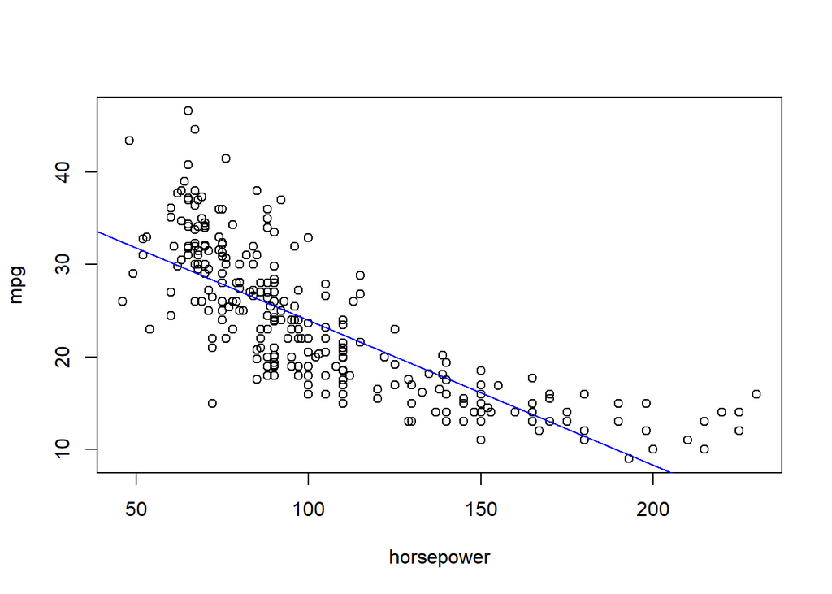

```r
# your code here

plot(train$mpg~train$horsepower,xlab = "horsepower", ylab = "mpg")
abline(lm(train$mpg~train$horsepower), pch=19,col= "blue")
```

```r
pred <- predict(lm1,data.frame(horsepower=98))
print(pred)
```

```
##        1
## 24.29381
```

## Step 5: Evaluate on the test data

- Test on the test data using the predict function
- Find the correlation between the predicted values and the mpg values in the test data
- Print the correlation
- Calculate the mse on the test results
- Print the mse
- Compare this to the mse for the training data
- Comment on the correlation and the mse in terms of whether the model was able to generalize well to the test data

```r
# your code here

pred2 <- predict(lm1,newdata=test)
corr <- cor(pred2,test$mpg)
print(corr)
```

```
## [1] 0.7642101
```

```r
lm2 <- lm(mpg~horsepower,data=test)
mse2 <- mean(lm2$residuals^2)
print(mse2)
```

```
## [1] 25.25282
```

```r
rmse2 <- sqrt(mse2)
print(rmse2)
```

```
## [1] 5.025218
```

## Step 6: Plot the residuals

- Plot the linear model in a 2x2 arrangement
- Do you see evidence of non-linearity from the residuals?

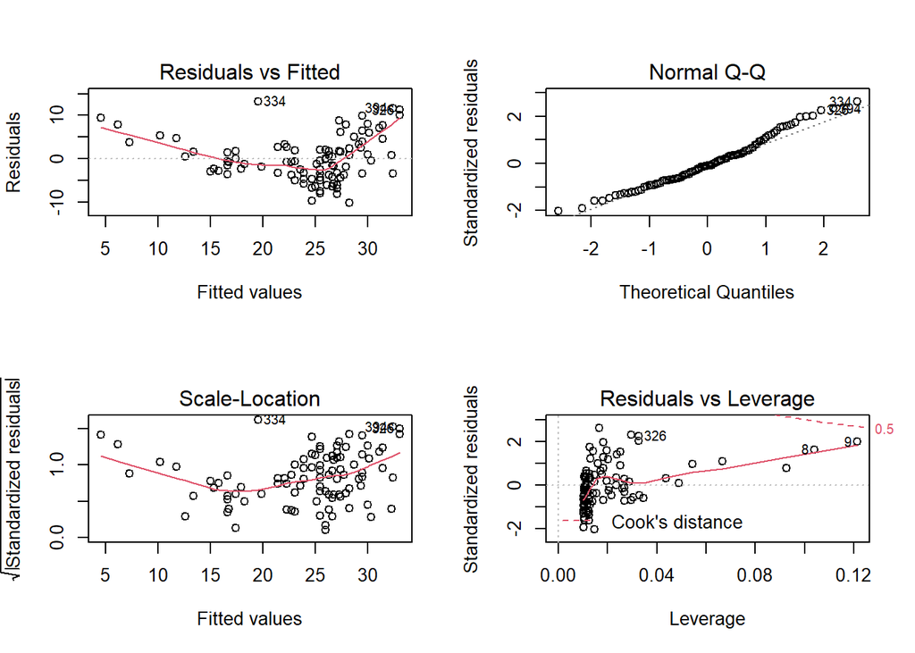

```r
# your code here
par(mfrow=c(2,2))
plot(lm2)
```

## Step 7: Create a second model

- Create a second linear model with log(mpg) predicted by horsepower
- Run summary() on this second model
- Compare the summary statistic R^2 of the two models

Your commentary here: The R^2 for this linear model(lm3) is higher than both lm1 and lm2.

```r
# your code here
logMpg <- log(train$mpg)
lm3 <- lm(logMpg~train$horsepower)
summary(lm3)
```

```
##
## Call:
## lm(formula = logMpg ~ train$horsepower)
##
## Residuals:
##      Min       1Q   Median       3Q      Max
## -0.62229 -0.12814  0.01443  0.12330  0.61150
##
## Coefficients:
##                    Estimate Std. Error t value Pr(>|t|)
## (Intercept)       3.8631645  0.0319324  120.98   <2e-16 ***
## train$horsepower -0.0074003  0.0002852  -25.95   <2e-16 ***
## ---
## Signif. codes:  0 '***' 0.001 '**' 0.01 '*' 0.05 '.' 0.1 ' ' 1
##
## Residual standard error: 0.1902 on 292 degrees of freedom
## Multiple R-squared:  0.6975, Adjusted R-squared:  0.6965
## F-statistic: 673.3 on 1 and 292 DF,  p-value: < 2.2e-16
```

```r
summary(lm2)
```

```
##
## Call:
## lm(formula = mpg ~ horsepower, data = test)
##
## Residuals:
##      Min       1Q   Median       3Q      Max
## -10.1967  -3.5773  -0.5345   2.7130  13.1946
##
## Coefficients:
##             Estimate Std. Error t value Pr(>|t|)
## (Intercept) 40.75077    1.51608   26.88   <2e-16 ***
## horsepower  -0.16095    0.01386  -11.61   <2e-16 ***
## ---
## Signif. codes:  0 '***' 0.001 '**' 0.01 '*' 0.05 '.' 0.1 ' ' 1
##
## Residual standard error: 5.077 on 96 degrees of freedom
## Multiple R-squared:  0.584,  Adjusted R-squared:  0.5797
## F-statistic: 134.8 on 1 and 96 DF,  p-value: < 2.2e-16
```

## Step 8: Evaluate the second model graphically

- Plot log(train$mpg)~train$horsepower
- Draw a blue abline()
- Comment on how well the line fits the data compared to model 1 above

Your commentary here: This line fits better than the one from model 1.

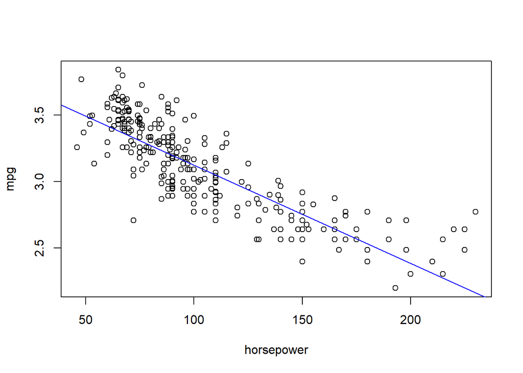

```r
# your code here
plot(logMpg~train$horsepower,xlab = "horsepower", ylab = "mpg")
abline(lm(logMpg~train$horsepower), pch=19,col= "blue")
```

## Step 9: Predict and evaluate on the second model

- Predict on the test data using lm2
- Find the correlation of the predictions and log() of test mpg, remembering to compare pred with log(test$mpg)
- Output this correlation
- Compare this correlation with the correlation you got for model
- Calculate and output the MSE for the test data on lm2, and compare to model 1. Hint: Compute the residuals and mse like this:

```
residuals <- pred - log(test$mpg)
mse <- mean(residuals^2)
```

Your commentary here: The correlation is noticeably higher than the other models. The MSE is much higher than model 1.

```r
# your code here
pred3 <- predict(lm2,newdata=test)
corr2 <- cor(pred3,log(test$mpg))
print(corr2)
```

```
## [1] 0.814936
```

```r
residuals <- pred3 -log(test$mpg)
mse3 <- mean(residuals^2)
print(mse3)
```

```
## [1] 475.6735
```

```r
rmse3 <- sqrt(mse3)
print(rmse3)
```

```
## [1] 21.80994
```

## Step 10: Plot the residuals of the second model

- Plot the second linear model in a 2x2 arrangement
- How does it compare to the first set of graphs?

Your commentary here: The second set is much better than the first set since the points are more clustered together Visibly seen by having much more concentrated areas resulting in darker, more filled areas on each graph.

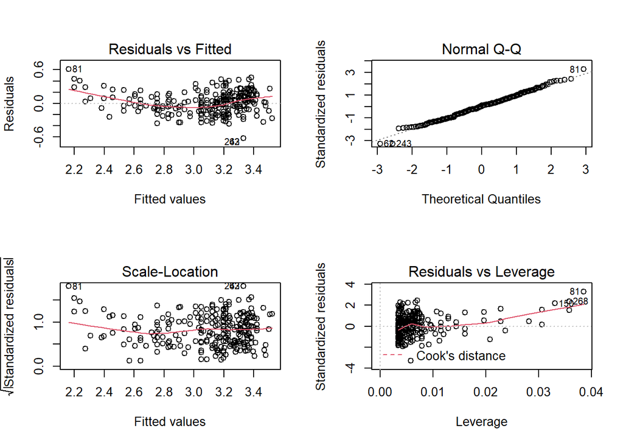

```r
# your code here
par(mfrow=c(2,2))
plot(lm3)
```